# **Panorama da inflação**

Os principais índices de inflação do Brasil, apontam em junho de 2007 um avanço da inflação de em média **0.28%**. Com esse resultado, no ano a inflação acumula uma variação média positiva de **1.75%**, e em 12 meses uma variação média acumulada de **3.85%**.

|  | Variação mensal | Variação acumulada no ano | Variação acumulada em 12 meses |
| --- | --- | --- | --- |
| IPCA | 0.28% | 2.08% | 3.69% |
| INPC | 0.31% | 2.2% | 3.97% |
| IGP-M | 0.26% | 0.96% | 3.89% |
| IGP-DI | 0.26% | 1.01% | 3.96% |
| IPA | 0.09% | 0.01% | 0.04% |
| IPC | 0.42% | 1.81% | 3.98% |
| INCC | 0.92% | 3.05% | 5.2% |

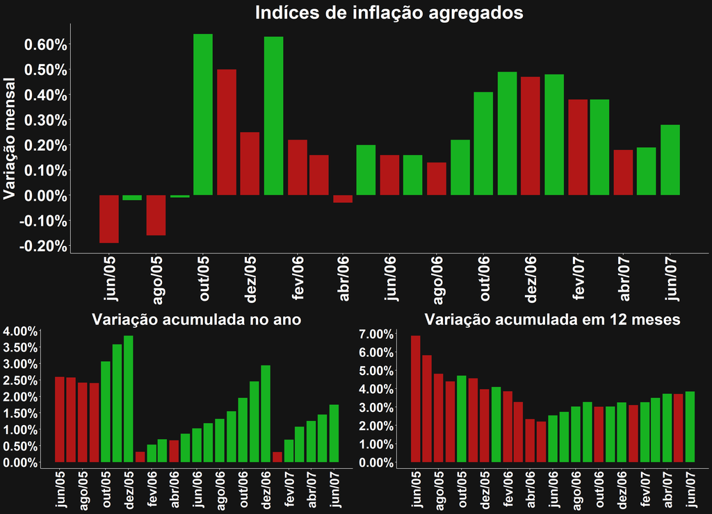

Índices selecionados para a média: IPCA, INPC e IGP-M.

# IPCA

O Indíce de Preços ao Consumidor Amplo (IPCA) variou 0.28% em junho, valor superior ao mesmo período do ano anterior quando apresentou uma taxa de -0.21%. Com esse resultado o indíce acumula no ano uma variação positiva de 2.08%, e em 12 meses uma variação positiva de 3.69%.

|  | 06/2006 | 05/2007 | 06/2007 |
| --- | --- | --- | --- |
| Variação mensal | -0.21% | 0.28% | 0.28% |
| Variação acumulada no ano | 1.54% | 1.79% | 2.08% |
| Variação acumulada em 12 meses | 4.03% | 3.18% | 3.69% |

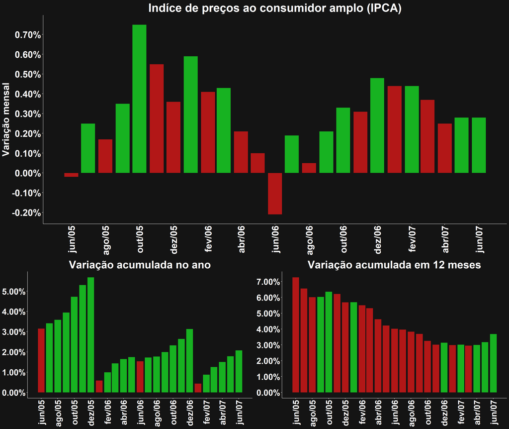

Os grupos que tiveram maior resultado positivo foram Alimentação e bebidas (1.09%) e Vestuário (0.91%), e negativo Artigos de residência (-0.65%) e Transportes (-0.4%).

|  | Variação mensal | Variação acumulada no ano | Peso mensal |
| --- | --- | --- | --- |
| Alimentação e bebidas | 1.09% | 3.94% | 20.69% |
| Habitação | 0.25% | 1.36% | 13.52% |
| Artigos de residência | -0.65% | -1.56% | 4.6% |
| Vestuário | 0.91% | 1.48% | 6.51% |
| Transportes | -0.4% | 1.05% | 20.76% |
| Saúde e cuidados pessoais | 0.32% | 2.58% | 10.82% |
| Despesas pessoais | 0.42% | 3.2% | 9.63% |
| Educação | 0.04% | 3.72% | 7.17% |
| Comunicação | -0.05% | 0.06% | 6.31% |

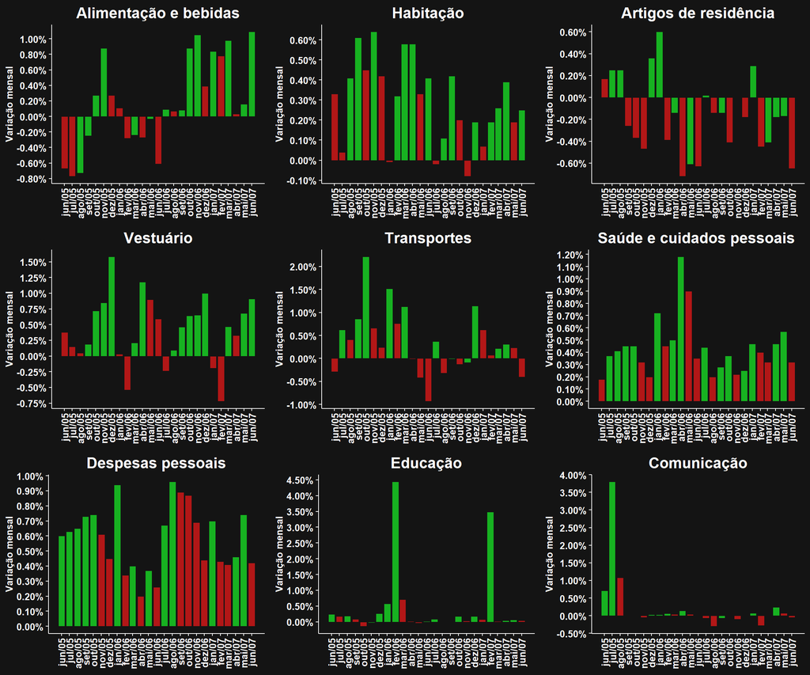

A nível de sub-itens os que mais influenciaram positivamente no resultado em relação ao seu peso foram Leite pasteurizado (12.4%%) e Refeição (1%%), e negativamente Etanol (-12.35%%) e Gasolina (-0.77%%).

|  | Variação mensal | Variação acumulada no ano | Peso mensal |
| --- | --- | --- | --- |
| Leite pasteurizado | 12.4% | 24.95% | 0.99% |
| Empregado doméstico | 1.11% | 4.84% | 2.99% |
| Refeição | 1% | 3.95% | 3.74% |
| Plano de saúde | 0.71% | 4.56% | 3.32% |

|  | Variação mensal | Variação acumulada no ano | Peso mensal |
| --- | --- | --- | --- |
| Gasolina | -0.77% | -0.5% | 4.61% |
| Etanol | -12.35% | 2.22% | 0.43% |
| Seguro voluntário de veículo | -3.14% | -7.85% | 0.44% |
| Boate, danceteria e discoteca | -3.5% | 1.41% | 0.45% |

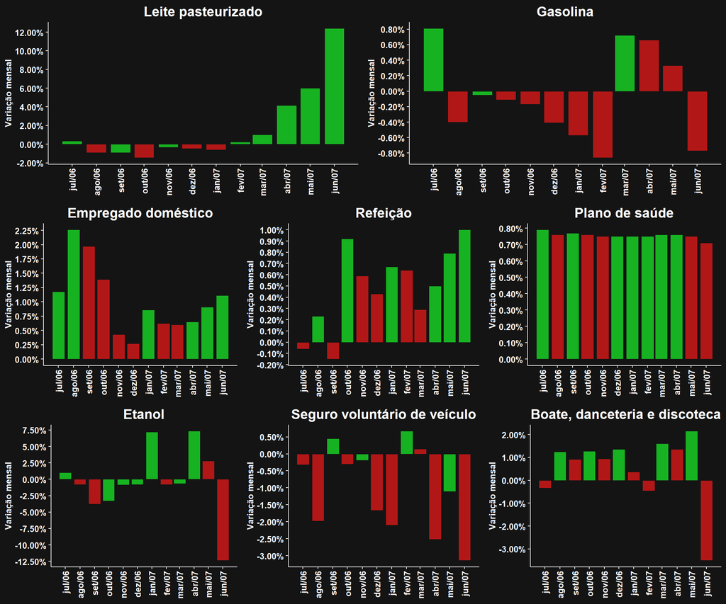

# INPC

O Indíce Nacional de Preços ao Consumidor (INPC) variou 0.31% em junho, valor superior ao mesmo período do ano anterior quando apresentou uma taxa de -0.07%. Com esse resultado o indíce acumula no ano uma variação positiva de 2.2%, e em 12 meses uma variação positiva de 3.97%.

|  | 06/2006 | 05/2007 | 06/2007 |
| --- | --- | --- | --- |
| Variação mensal | -0.07% | 0.26% | 0.31% |
| Variação acumulada no ano | 1.06% | 1.88% | 2.2% |
| Variação acumulada em 12 meses | 2.79% | 3.57% | 3.97% |

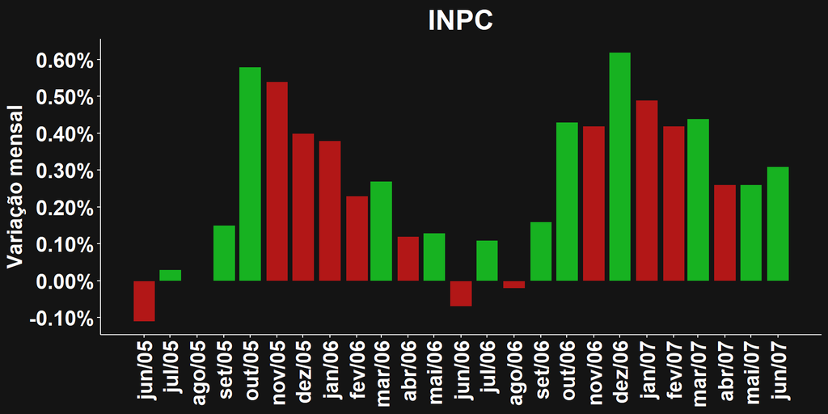

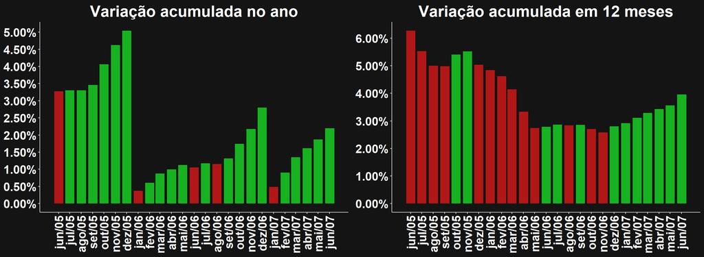

# IGP-M

|  | 06/2006 | 05/2007 | 06/2007 |
| --- | --- | --- | --- |
| Variação mensal | 0.75% | 0.04% | 0.26% |
| Variação acumulada no ano | 0.48% | 0.69% | 0.96% |
| Variação acumulada em 12 meses | 0.86% | 4.4% | 3.89% |

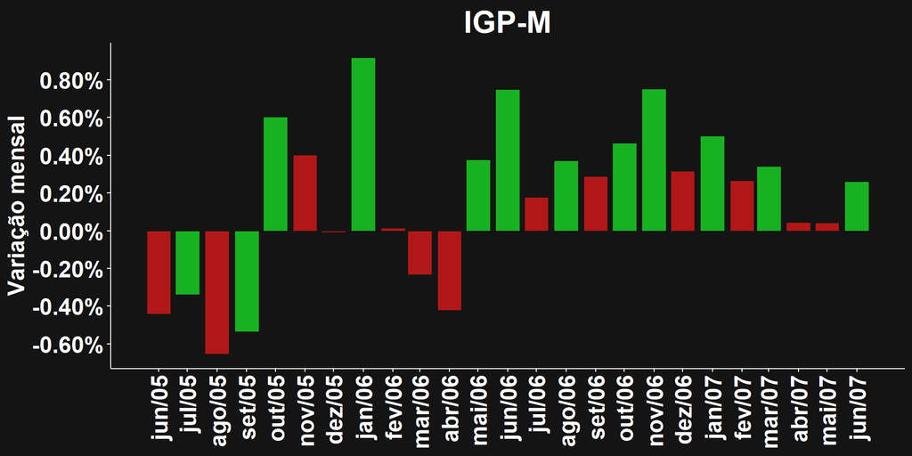

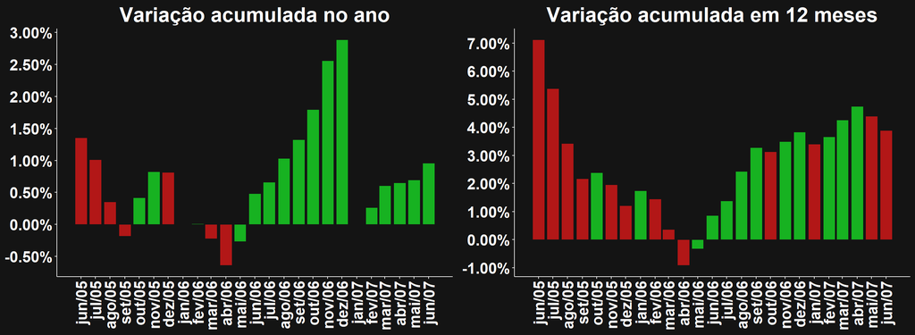

# IGP-DI

|  | 06/2006 | 05/2007 | 06/2007 |
| --- | --- | --- | --- |
| Variação mensal | 0.67% | 0.16% | 0.26% |
| Variação acumulada no ano | 0.55% | 0.75% | 1.01% |
| Variação acumulada em 12 meses | 0.98% | 4.38% | 3.96% |

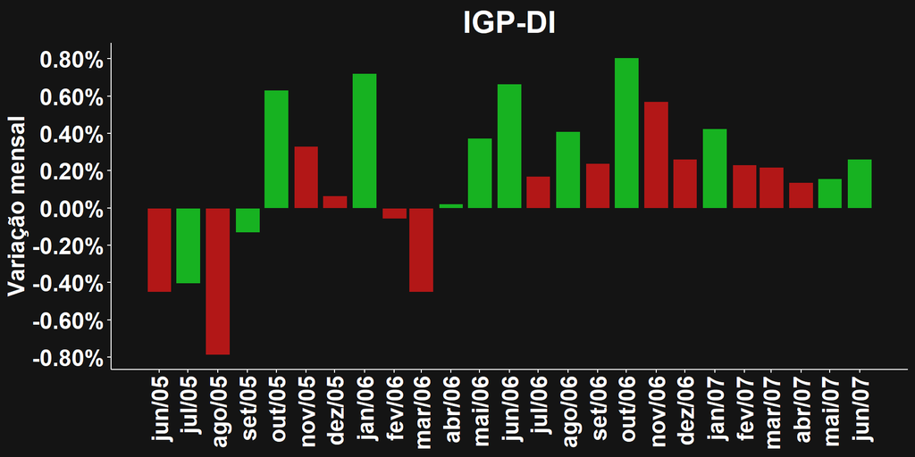

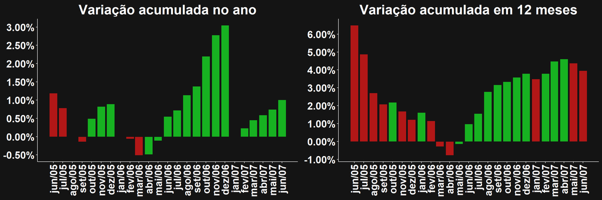

[output not shown]

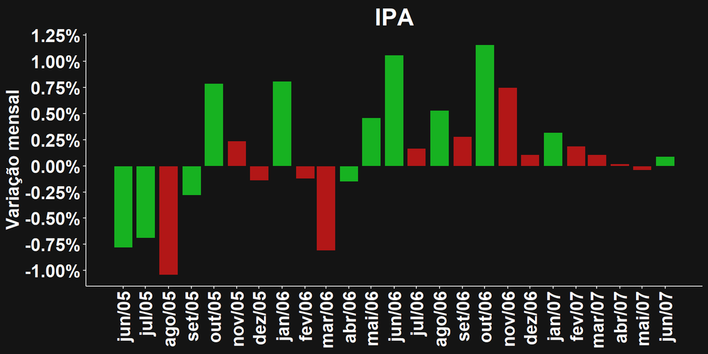

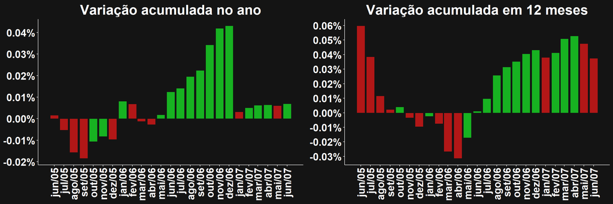

O Indíce de Preços ao Consumidor (IPC), integrante do IGP-DI com peso de 30%, apresentou variação de 0.42% em junho, valor superior ao mesmo período do ano anterior quando apresentou uma taxa de -0.4%. Com esse resultado o indíce acumula no ano uma variação positiva de 1.81%, e em 12 meses uma variação positiva de 3.98%.

|  | 06/2006 | 05/2007 | 06/2007 |
| --- | --- | --- | --- |
| Variação mensal | -0.4% | 0.25% | 0.42% |
| Variação acumulada no ano | -0.03% | 1.39% | 1.81% |
| Variação acumulada em 12 meses | 1.86% | 3.12% | 3.98% |

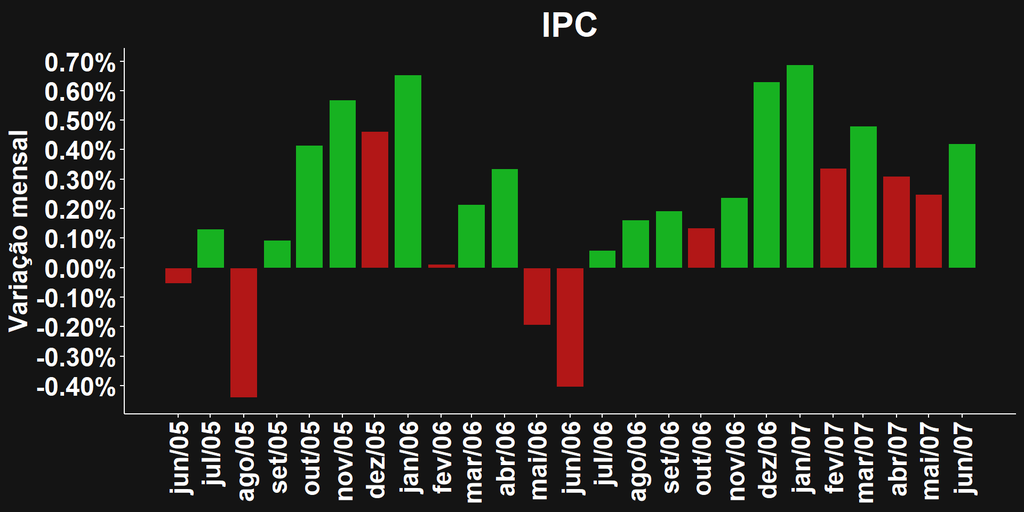

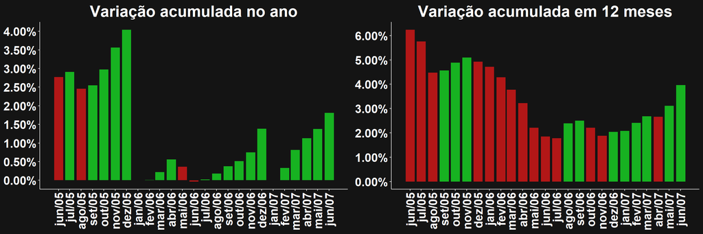

O Indíce Nacional de Custos de Construção (INCC), integrante do IGP-DI com peso de 10%, apresentou variação de 0.92% em junho, valor superior ao mesmo período do ano anterior quando apresentou uma taxa de 0.9%. Com esse resultado o indíce acumula no ano uma variação positiva de 3.05%, e em 12 meses uma variação positiva de 5.2%.

|  | 06/2006 | 05/2007 | 06/2007 |
| --- | --- | --- | --- |
| Variação mensal | 0.9% | 1.15% | 0.92% |
| Variação acumulada no ano | 3% | 2.1% | 3.05% |
| Variação acumulada em 12 meses | 4.62% | 5.18% | 5.2% |

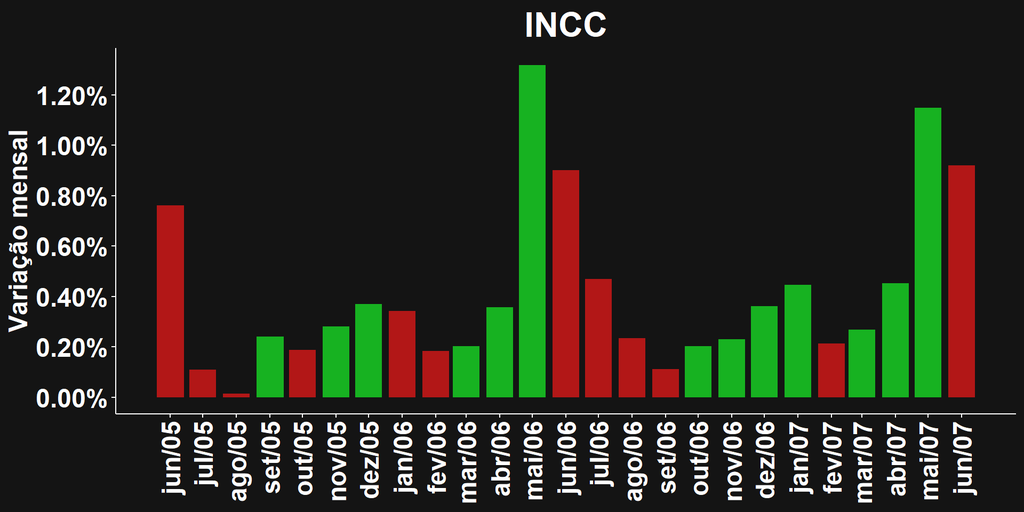

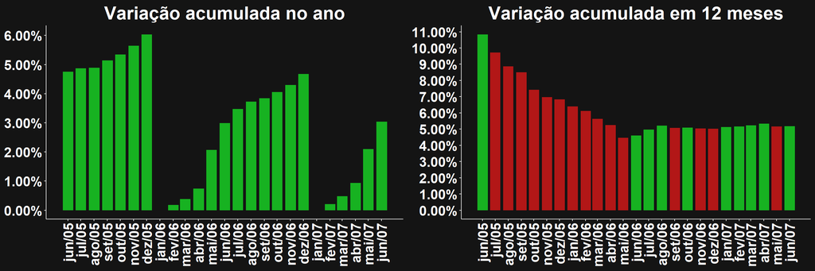

# Estatísticas

As estatísticas descritivas a seguir são feitas com base nos últimos 48 meses, e tem como objetivo possibilitar a avaliação do resultado observado em comparação aos períodos anteriores.

|  | Minimo | 1 Quartil | Mediana | Media | 3 Quartil | Maximo | Desvio Padrão |
| --- | --- | --- | --- | --- | --- | --- | --- |
| IPCA | -0.21% | 0.28% | 0.42% | 0.43% | 0.59% | 0.91% | 0.24% |
| INPC | -0.11% | 0.17% | 0.4% | 0.38% | 0.54% | 0.91% | 0.25% |
| IGP-M | -0.65% | 0.14% | 0.39% | 0.43% | 0.77% | 1.38% | 0.52% |
| IGP-DI | -0.79% | 0.17% | 0.43% | 0.44% | 0.74% | 1.46% | 0.5% |
| IPA | -1.04% | 0.06% | 0.46% | 0.44% | 0.86% | 1.71% | 0.7% |
| IPC | -0.44% | 0.16% | 0.34% | 0.37% | 0.63% | 1.08% | 0.32% |
| INCC | 0.02% | 0.24% | 0.49% | 0.63% | 0.91% | 2.09% | 0.46% |

Levando em consideração o desvio padrão de cada indíce, proporcionalmente os que mais se afastaram da média foram o INCC, o IPCA e o IPA.

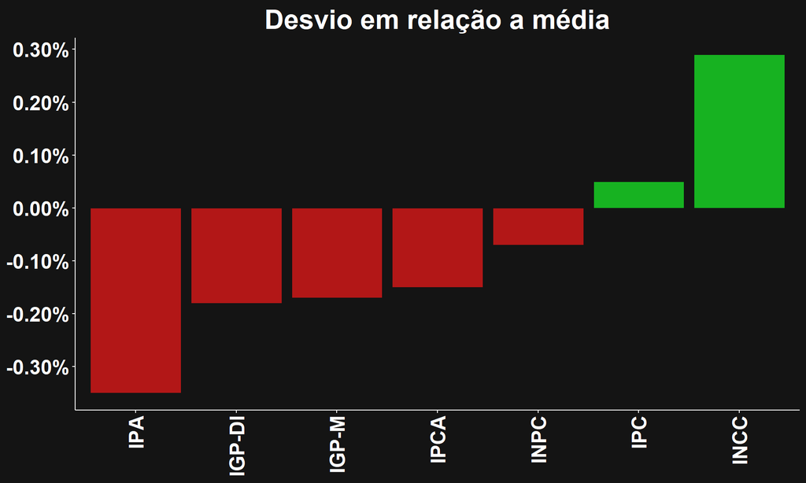

**João Victor Gomes**  
**jvg.santana@gmail.com**  
**[linkedin.com/in/jvictorgomes](https://www.linkedin.com/in/jvictorgomes/)**